# Zaliczenie przedmiotu ‘Machine Learning’

Studia podyplomowe: ‘Metody Statystycznej Analizy Danych - edycja IX’

Jędrzej Szelc

2024-05-13

# 1. Wstęp

## 1.1. Treść zadania

Wybieram zadanie numer 2.

Treść zadania:

*“Na podstawie wybranego zestawu danych dokonać wstępnej analizy danych (EDA), a następnie z wykorzystaniem trzech wybranych technik (m.in. kNN, nB, regresja logistyczna, drzewa decyzyjne, lasy losowe itp.) zbudować model prognostyczny. W ramach sprawozdania zwrócić uwagę na: podział danych na zbiór uczący i testowy (walidacja krzyżowa), dokonać optymalizacji hiperparametrów, na podstawy odpowiednich indeksów opisać wyniki i zdecydować się, który z modeli jest najskuteczniejszy.”*

## 1.2. Konfiguracja wstępna

```r
### Import bibliotek i modułów:
library(dplyr)
library(ggplot2)
library(class)
library(caret)
library(kknn)
library(rpart)
library(randomForest)

### Konfiguracja grafiki:
string_kolor_punktu_danych_na_wykresach <- "steelblue"
integer_rozmiar_punktu_danych_na_wykresach <- 1

### Funkcje pomocnicze:
funkcja_konwersja_wartosci_wektora_na_procenty <- function(wektor_wejsciowy, integer_zaokraglenie)
{
  wektor_przeznaczenie_kredytu_wszystkie_wartosci <-
    round(wektor_wejsciowy/
            sum(wektor_wejsciowy) * 100 , integer_zaokraglenie)
}
```

# 2. Dane oraz EDA

W niniejszym rozdziale przeprowadzone zostaną import, wstępna obróbka oraz Eksploracyjna Analiza Danych (EDA).

Do budowy modelu wybieram dane niemieckich kredytobiorców - plik: *“german_credit_data.csv”*.

## 2.1. Import danych

```r
string_plik_z_danymi <- "german_credit_data.csv"
string_sciezka_dostepu <- getwd()
string_sciezka_dostepu <- paste0(string_sciezka_dostepu, "/",
                                 string_plik_z_danymi)
df_dane <- read.csv(string_sciezka_dostepu, sep=";",
                    stringsAsFactors=TRUE)
```

## 2.2. Wstępna obróbka danych

```r
### Usuwam dane niepełne (czyli dane, które mogą gdziekolwiek zawierać wartości N/A):
df_dane <- na.omit(df_dane)

### Spoglądam wstępnie na dane:
head(df_dane)
```

```
##    Age    Sex Job Housing Saving.accounts Checking.account Credit.amount
## 2   22 female   2     own          little         moderate          5951
## 4   45   male   2    free          little           little          7882
## 5   53   male   2    free          little           little          4870
## 8   35   male   3    rent          little         moderate          6948
## 10  28   male   3     own          little         moderate          5234
## 11  25 female   2    rent          little         moderate          1295
##    Duration             Purpose
## 2        48            radio/TV
## 4        42 furniture/equipment
## 5        24                 car
## 8        36                 car
## 10       30                 car
## 11       12                 car
```

```r
summary(df_dane)
```

```
##       Age            Sex           Job        Housing      Saving.accounts
##  Min.   :19.00   female:168   Min.   :0.000   free: 65   little    :412
##  1st Qu.:26.00   male  :354   1st Qu.:2.000   own :349   moderate  : 64
##  Median :31.50                Median :2.000   rent:108   quite rich: 23
##  Mean   :34.89                Mean   :1.875              rich      : 23
##  3rd Qu.:41.00                3rd Qu.:2.000
##  Max.   :75.00                Max.   :3.000
##
##  Checking.account Credit.amount      Duration                    Purpose
##  little  :245     Min.   :  276   Min.   : 6.00   car                :173
##  moderate:224     1st Qu.: 1298   1st Qu.:12.00   radio/TV           :132
##  rich    : 53     Median : 2326   Median :18.00   furniture/equipment:107
##                   Mean   : 3279   Mean   :21.34   business           : 53
##                   3rd Qu.: 3971   3rd Qu.:26.75   education          : 28
##                   Max.   :18424   Max.   :72.00   repairs            : 14
##                                                   (Other)            : 15
```

```r
str(df_dane)
```

```
## 'data.frame':    522 obs. of  9 variables:
##  $ Age             : int  22 45 53 35 28 25 24 22 60 28 ...
##  $ Sex             : Factor w/ 2 levels "female","male": 1 2 2 2 2 1 1 1 2 1 ...
##  $ Job             : int  2 2 2 3 3 2 2 2 1 2 ...
##  $ Housing         : Factor w/ 3 levels "free","own","rent": 2 1 1 3 2 3 3 2 2 3 ...
##  $ Saving.accounts : Factor w/ 4 levels "little","moderate",..: 1 1 1 1 1 1 1 1 1 1 ...
##  $ Checking.account: Factor w/ 3 levels "little","moderate",..: 2 1 1 2 2 2 1 2 1 1 ...
##  $ Credit.amount   : int  5951 7882 4870 6948 5234 1295 4308 1567 1199 1403 ...
##  $ Duration        : int  48 42 24 36 30 12 48 12 24 15 ...
##  $ Purpose         : Factor w/ 8 levels "business","car",..: 6 5 2 2 2 2 1 6 2 2 ...
##  - attr(*, "na.action")= 'omit' Named int [1:478] 1 3 6 7 9 17 18 20 21 25 ...
##   ..- attr(*, "names")= chr [1:478] "1" "3" "6" "7" ...
```

```r
### Zmiana nazw kolumn ramki danych:
colnames(df_dane) <- c("Wiek",
                       "Płeć",
                       "Zatrudnienie",
                       "Nieruchomości",
                       "Rachunek_oszczędnościowy",
                       "Rachunek_bieżący",
                       "Wysokość_kredytu",
                       "Okres_kredytowania",
                       "Przeznaczenie_kredytu")

### Zmiana poziomów zmiennych typu "factor" w ramce danych:
levels(df_dane$Płeć) <- c("Kobieta", "Mężczyzna")
levels(df_dane$Rachunek_oszczędnościowy) <- c("Niskie",
                                              "Umiarkowane",
                                              "Średniowysokie",
                                              "Wysokie")

levels(df_dane$Rachunek_bieżący) <- c("Niskie",
                                      "Umiarkowane",
                                      "Wysokie")

levels(df_dane$Nieruchomości) <- c("Socjalne",
                                   "Własnościowe",
                                   "Najem")

levels(df_dane$Przeznaczenie_kredytu) <- c("Biznes",
                                           "Samochód",
                                           "AGD",
                                           "Edukacja",
                                           "Meble",
                                           "RTV",
                                           "Remont",
                                           "Wakacje")
```

## 2.3. EDA

W kolejnych podsekcjach eksploruję zależności danej zmiennej od pozostałych.

### 2.3.1. Wiek

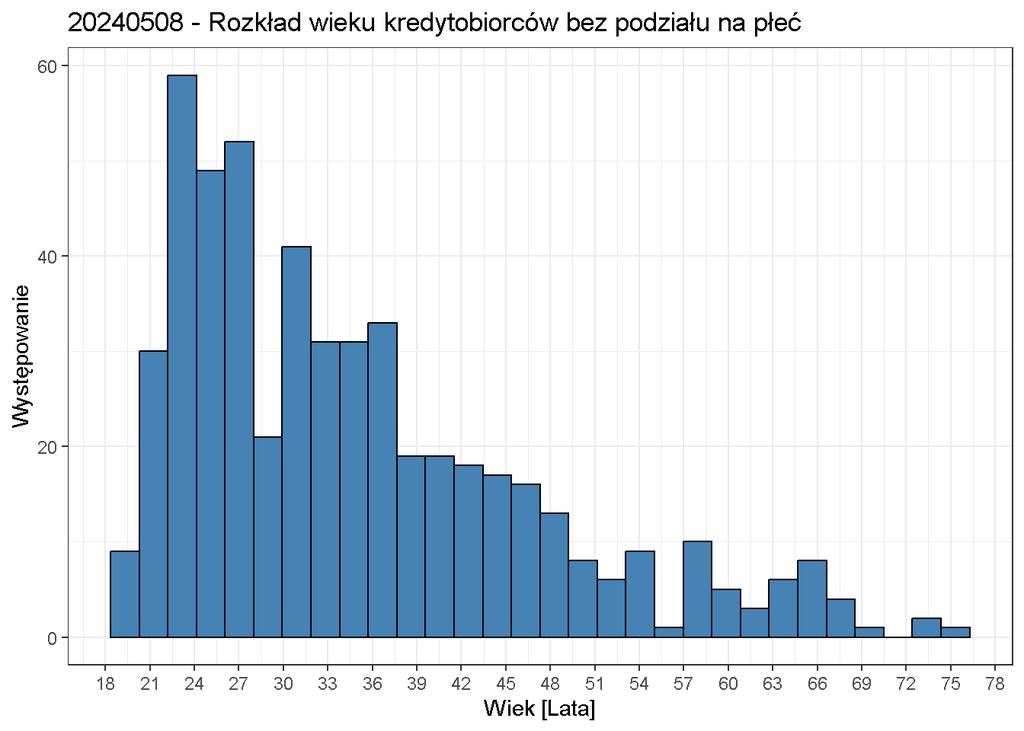

```r
### Wiek kredytobiorców bez podziału na płeć:
df_dane %>%
  ggplot() +
  geom_histogram(aes(x = Wiek),
                 fill = "steelblue",
                 colour = "black") +
  theme_bw() +
  labs(title = "20240508 - Rozkład wieku kredytobiorców bez podziału na płeć",
       x = "Wiek [Lata]", y = "Występowanie") +
  scale_x_continuous(breaks=seq(18, 78, by=3))
```

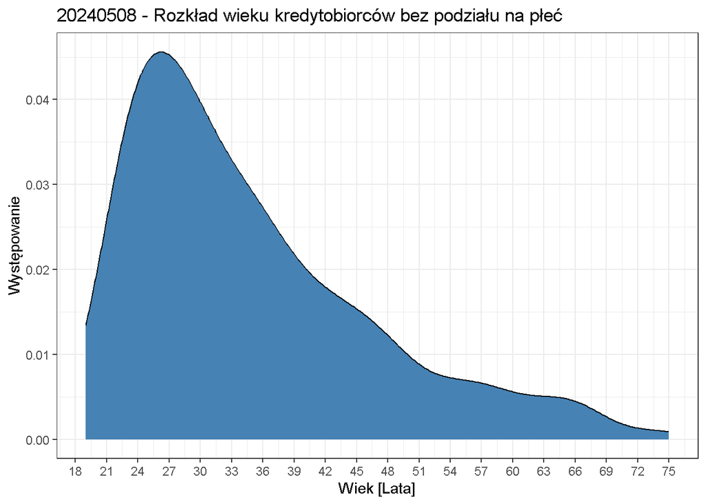

```r
df_dane %>%
  ggplot() +
  geom_density(aes(x = Wiek),
               fill = "steelblue",
               colour = "black") +
  theme_bw() +
  labs(title = "20240508 - Rozkład wieku kredytobiorców bez podziału na płeć",
       x = "Wiek [Lata]", y = "Występowanie") +
  scale_x_continuous(breaks=seq(18, 78, by=3))
```

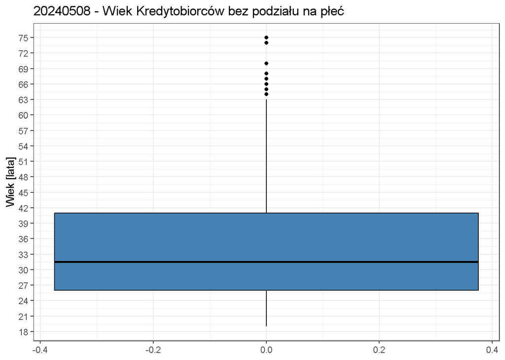

```r
df_dane %>%
  ggplot() +
  geom_boxplot(aes(y = Wiek),
               fill = "steelblue",
               colour = "black") +
  theme_bw() +
  labs(title = "20240508 - Wiek Kredytobiorców bez podziału na płeć",
       y = "Wiek [lata]") +
  scale_y_continuous(breaks=seq(18, 78, by=3))
```

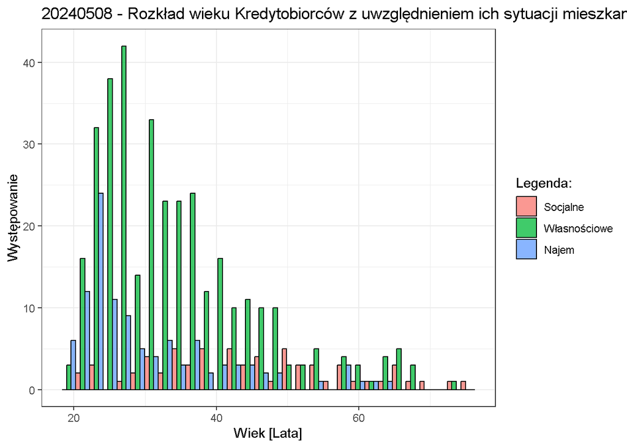

```r
### Nieruchomości, a wiek:
df_dane %>%
  ggplot() +
  geom_histogram(aes(x = Wiek, fill = Nieruchomości),
                 alpha = 0.75, position = "dodge",
                 colour = "black") +
  theme_bw() +
  labs(title = "20240508 - Rozkład wieku Kredytobiorców z uwzględnieniem ich sytuacji mieszkaniowej oraz płci",
       x = "Wiek [Lata]", y = "Występowanie", fill="Legenda:")
```

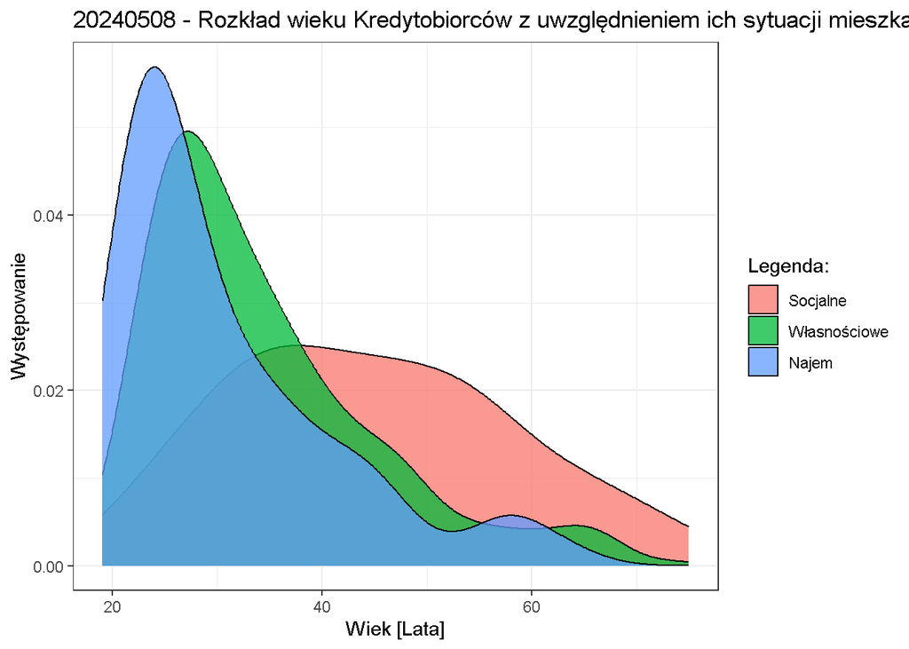

```r
df_dane %>%
  ggplot() +
  geom_density(aes(x = Wiek, fill = Nieruchomości),
                 alpha = 0.75,
                 colour = "black") +
  theme_bw() +
  labs(title = "20240508 - Rozkład wieku Kredytobiorców z uwzględnieniem ich sytuacji mieszkaniowej oraz płci",
       x = "Wiek [Lata]", y = "Występowanie", fill="Legenda:")
```

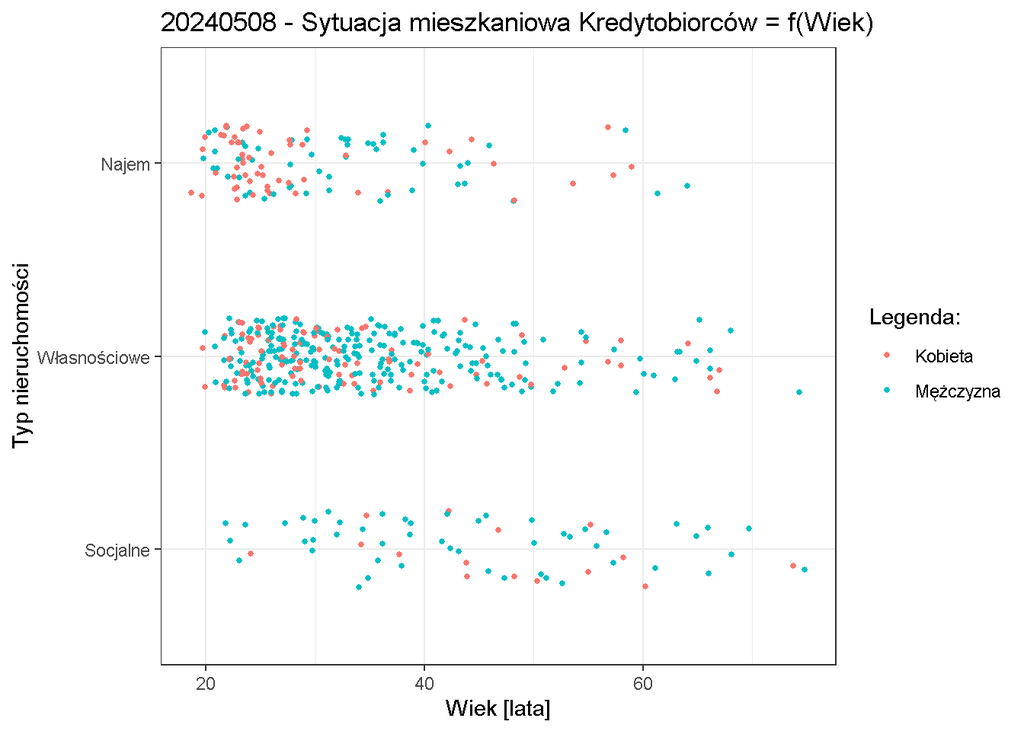

```r
df_dane %>%
  ggplot() +
  geom_jitter(aes(x = Wiek, y = Nieruchomości, col = Płeć),
              height = 0.2,
              size = integer_rozmiar_punktu_danych_na_wykresach) +
  theme_bw() +
  labs(title = "20240508 - Sytuacja mieszkaniowa Kredytobiorców = f(Wiek)",
       x = "Wiek [lata]", y = "Typ nieruchomości",
       col = "Legenda:")
```

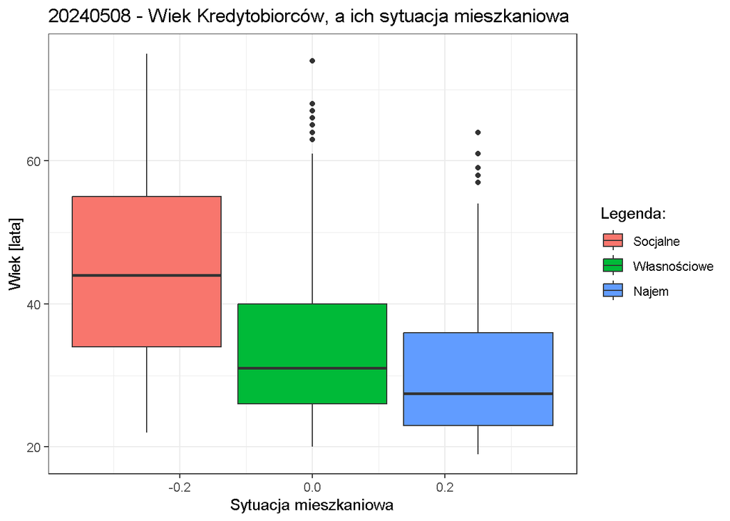

```r
df_dane %>%
  ggplot() +
  geom_boxplot(aes(y = Wiek, fill = Nieruchomości)) +
  theme_bw() +
  labs(title = "20240508 - Wiek Kredytobiorców, a ich sytuacja mieszkaniowa",
       x = "Sytuacja mieszkaniowa", y = "Wiek [lata]", fill = "Legenda:")
```

### 2.3.2. Płeć

```r
### Płeć badanych:
wektor_kobiety_meczyzni_w_badanej_probie <- table(df_dane$Płeć)
names(wektor_kobiety_meczyzni_w_badanej_probie) <- c("Kobiety [Liczba]",
                                                     "Mężczyni [Liczba]")
wektor_procent_kobiety_mezczyzni_w_badanej_probie <-
  funkcja_konwersja_wartosci_wektora_na_procenty(wektor_kobiety_meczyzni_w_badanej_probie,1)
names(wektor_procent_kobiety_mezczyzni_w_badanej_probie) <- c("Kobiety [%]",
                                                              "Mężczyni [%]")
wektor_kobiety_meczyzni_w_badanej_probie
```

```
##  Kobiety [Liczba] Mężczyni [Liczba]
##               168               354
```

```r
wektor_procent_kobiety_mezczyzni_w_badanej_probie
```

```
##  Kobiety [%] Mężczyni [%]
##         32.2         67.8
```

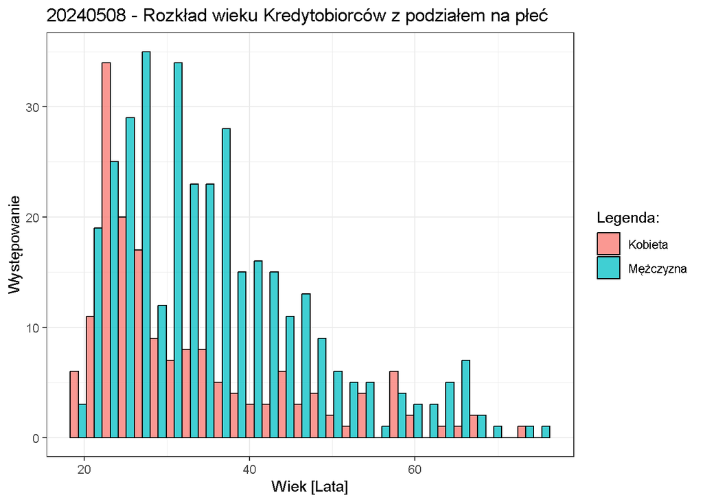

```r
### Płeć, a wiek:
df_dane %>%
  ggplot() +
  geom_histogram(aes(x = Wiek, fill = Płeć),
                 alpha = 0.75, position = "dodge",
                 colour = "black") +
  theme_bw() +
  labs(title = "20240508 - Rozkład wieku Kredytobiorców z podziałem na płeć",
       x = "Wiek [Lata]", y = "Występowanie", fill="Legenda:")
```

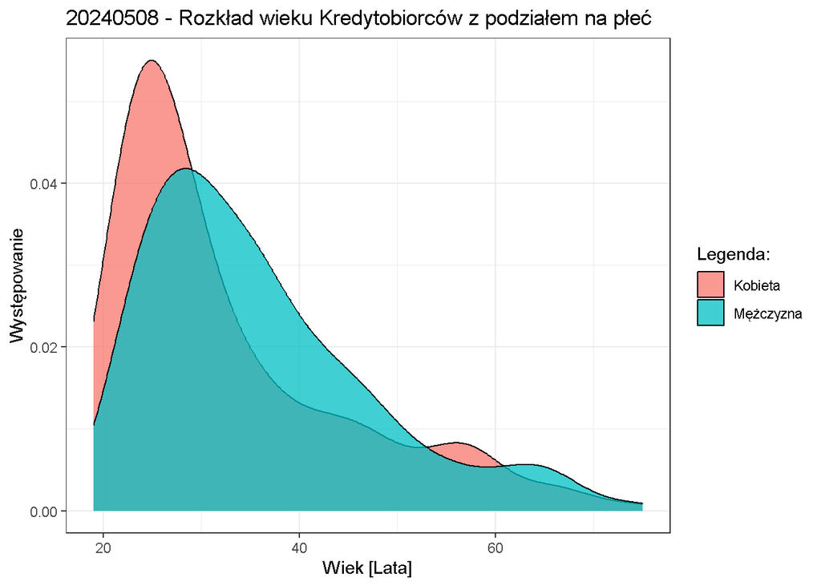

```r
df_dane %>%
  ggplot() +
  geom_density(aes(x = Wiek, fill = Płeć),
               alpha = 0.75,
               colour = "black") +
  theme_bw() +
  labs(title = "20240508 - Rozkład wieku Kredytobiorców z podziałem na płeć",
       x = "Wiek [Lata]", y = "Występowanie", fill="Legenda:")
```

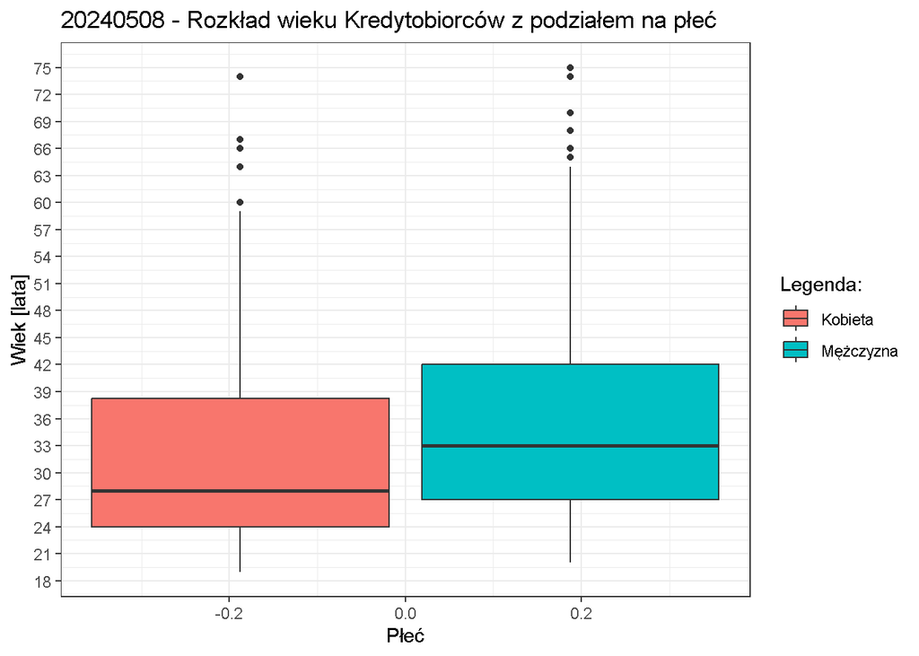

```r
df_dane %>%
  ggplot() +
  geom_boxplot(aes(y = Wiek, fill = Płeć)) +
  theme_bw() +
  labs(title = "20240508 - Rozkład wieku Kredytobiorców z podziałem na płeć",
       x = "Płeć", y = "Wiek [lata]", fill = "Legenda:") +
  scale_y_continuous(breaks=seq(18, 78, by=3))
```

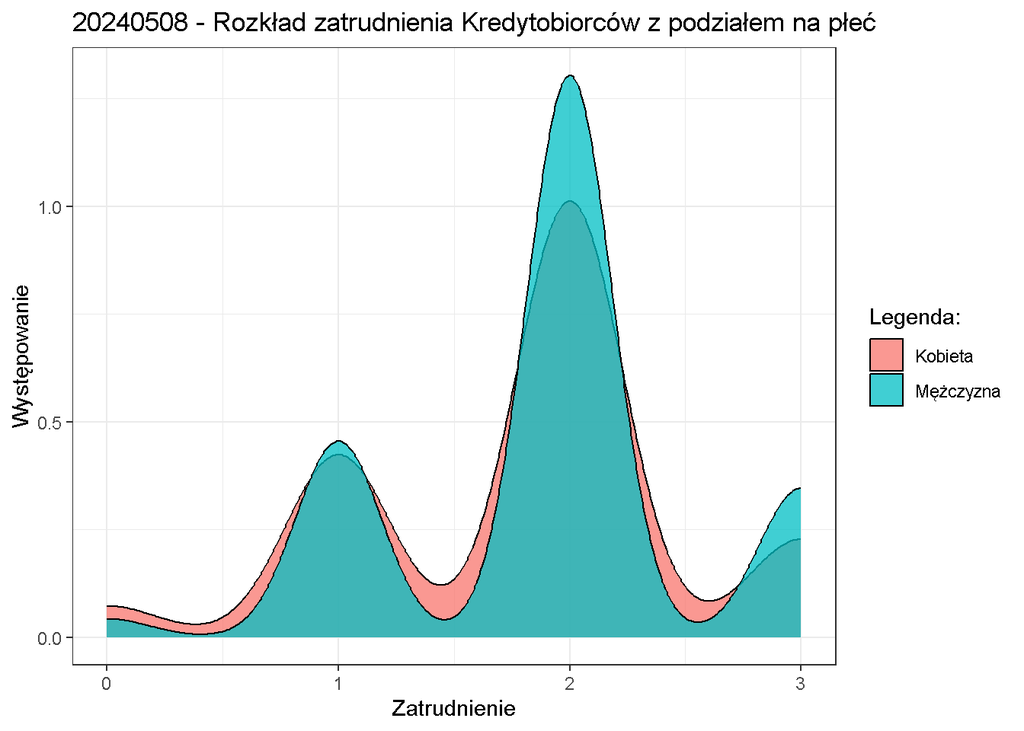

```r
### Płeć, a zatrudnienie:
df_dane %>%
  ggplot() +
  geom_density(aes(x = Zatrudnienie, fill = Płeć),
               alpha = 0.75,
               colour = "black") +
  theme_bw() +
  labs(title = "20240508 - Rozkład zatrudnienia Kredytobiorców z podziałem na płeć",
       x = "Zatrudnienie", y = "Występowanie", fill="Legenda:")
```

```r
### Płeć, a sytuacja mieszkaniowa:
table(df_dane$Nieruchomości, df_dane$Płeć)
```

```
##
##                Kobieta Mężczyzna
##   Socjalne          15        50
##   Własnościowe      98       251
##   Najem             55        53
```

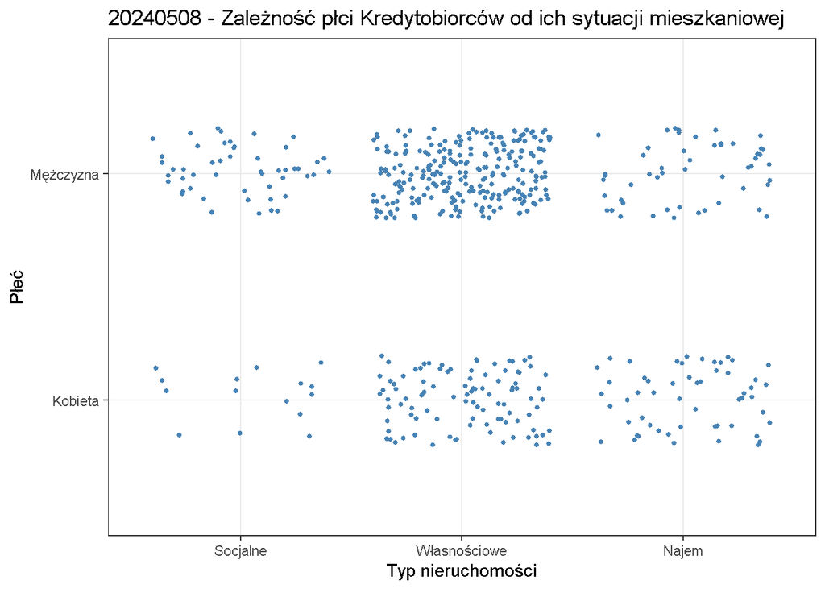

```r
df_dane %>%
  ggplot() +
  geom_jitter(aes(x = Nieruchomości, y = Płeć),
              height = 0.2,
              color = string_kolor_punktu_danych_na_wykresach,
              size = integer_rozmiar_punktu_danych_na_wykresach) +
  theme_bw() +
  labs(title = "20240508 - Zależność płci Kredytobiorców od ich sytuacji mieszkaniowej",
       y = "Płeć", x = "Typ nieruchomości",
       col = "Legenda:")
```

```r
### Płeć, a oszczędności:
table(df_dane$Rachunek_oszczędnościowy, df_dane$Płeć)
```

```
##
##                  Kobieta Mężczyzna
##   Niskie             133       279
##   Umiarkowane         18        46
##   Średniowysokie       7        16
##   Wysokie             10        13
```

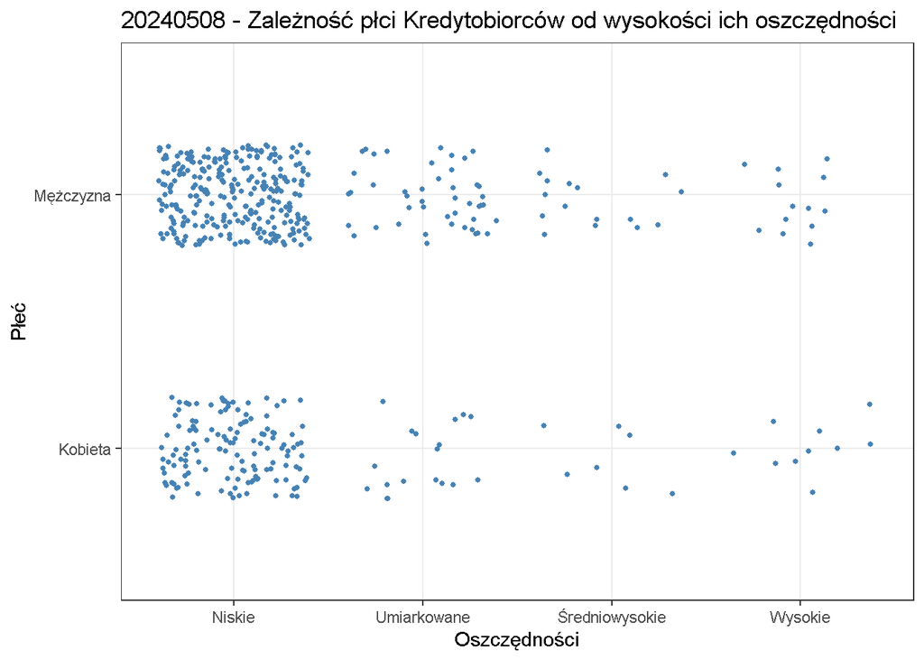

```r
df_dane %>%
  ggplot() +
  geom_jitter(aes(x = Rachunek_oszczędnościowy, y = Płeć),
              height = 0.2,
              color = string_kolor_punktu_danych_na_wykresach,
              size = integer_rozmiar_punktu_danych_na_wykresach) +
  theme_bw() +
  labs(title = "20240508 - Zależność płci Kredytobiorców od wysokości ich oszczędności",
       y = "Płeć", x = "Oszczędności",
       col = "Legenda:")
```

```r
### Płeć, a rachunek bieżący:
table(df_dane$Rachunek_bieżący, df_dane$Płeć)
```

```
##
##               Kobieta Mężczyzna
##   Niskie           76       169
##   Umiarkowane      73       151
##   Wysokie          19        34
```

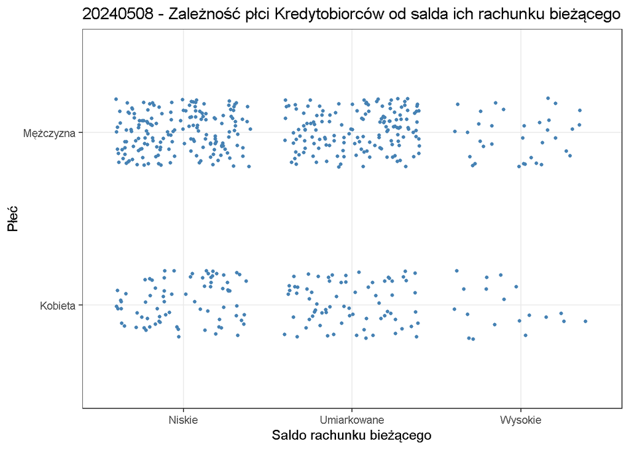

```r
df_dane %>%
  ggplot() +
  geom_jitter(aes(x = Rachunek_bieżący, y = Płeć),
              height = 0.2,
              color = string_kolor_punktu_danych_na_wykresach,
              size = integer_rozmiar_punktu_danych_na_wykresach) +
  theme_bw() +
  labs(title = "20240508 - Zależność płci Kredytobiorców od salda ich rachunku bieżącego",
       y = "Płeć", x = "Saldo rachunku bieżącego",
       col = "Legenda:")
```

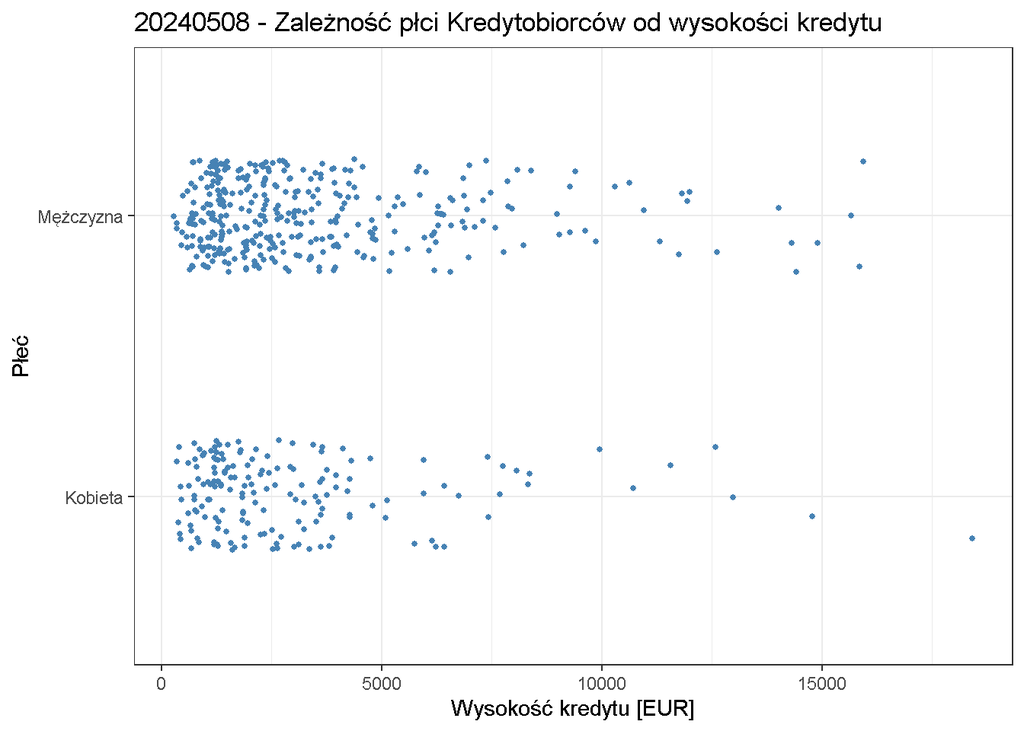

```r
### Płeć, a wysokość kredytu:
df_dane %>%
  ggplot() +
  geom_jitter(aes(x = Wysokość_kredytu, y = Płeć),
              height = 0.2,
              color = string_kolor_punktu_danych_na_wykresach,
              size = integer_rozmiar_punktu_danych_na_wykresach) +
  theme_bw() +
  labs(title = "20240508 - Zależność płci Kredytobiorców od wysokości kredytu",
       y = "Płeć", x = "Wysokość kredytu [EUR]",
       col = "Legenda:")
```

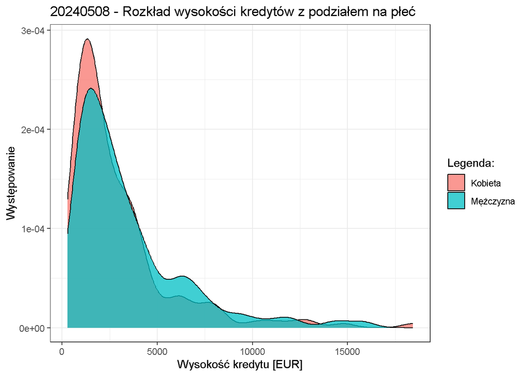

```r
df_dane %>%
  ggplot() +
  geom_density(aes(x = Wysokość_kredytu, fill = Płeć),
               alpha = 0.75,
               colour = "black") +
  theme_bw() +
  labs(title = "20240508 - Rozkład wysokości kredytów z podziałem na płeć",
       x = "Wysokość kredytu [EUR]", y = "Występowanie", fill="Legenda:")
```

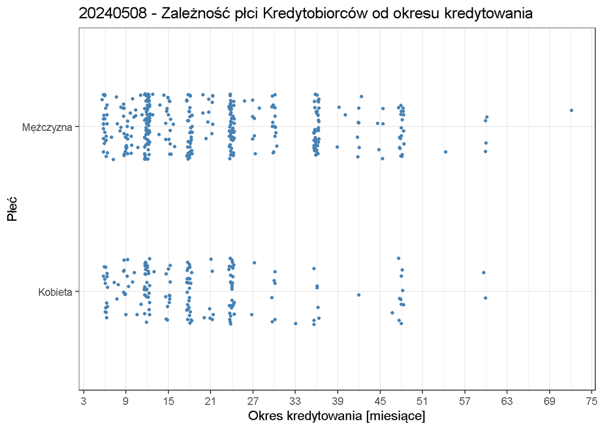

```r
### Płeć, a okres kredytowania:
df_dane %>%
  ggplot() +
  geom_jitter(aes(x = Okres_kredytowania, y = Płeć),
              height = 0.2,
              color = string_kolor_punktu_danych_na_wykresach,
              size = integer_rozmiar_punktu_danych_na_wykresach) +
  theme_bw() +
  labs(title = "20240508 - Zależność płci Kredytobiorców od okresu kredytowania",
       y = "Płeć", x = "Okres kredytowania [miesiące]",
       col = "Legenda:") + scale_x_continuous(breaks=seq(3, 78, by=6))
```

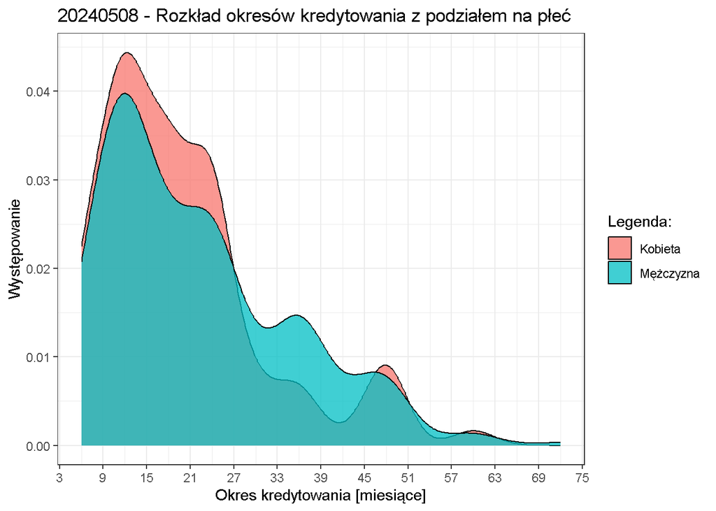

```r
df_dane %>%
  ggplot() +
  geom_density(aes(x = Okres_kredytowania, fill = Płeć),
               alpha = 0.75,
               colour = "black") +
  theme_bw() +
  labs(title = "20240508 - Rozkład okresów kredytowania z podziałem na płeć",
       x = "Okres kredytowania [miesiące]", y = "Występowanie", fill="Legenda:") +
  scale_x_continuous(breaks=seq(3, 78, by=6))
```

```r
### Płeć, a przeznaczenie kredytu:
table(df_dane$Przeznaczenie_kredytu, df_dane$Płeć)
```

```
##
##            Kobieta Mężczyzna
##   Biznes        12        41
##   Samochód      46       127
##   AGD            2         4
##   Edukacja      12        16
##   Meble         44        63
##   RTV           46        86
##   Remont         3        11
##   Wakacje        3         6
```

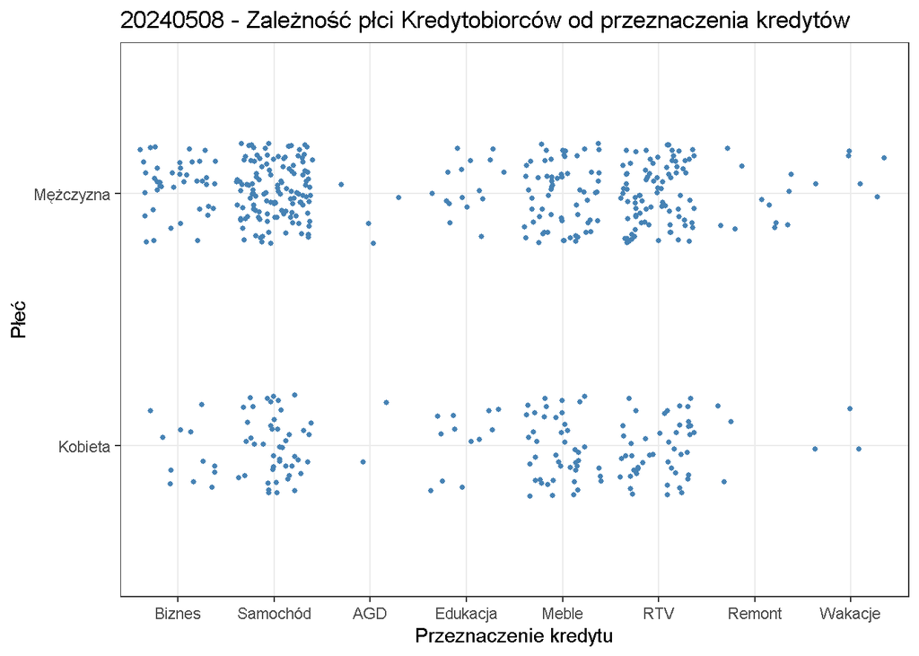

```r
df_dane %>%
  ggplot() +
  geom_jitter(aes(x = Przeznaczenie_kredytu, y = Płeć),
              height = 0.2,
              color = string_kolor_punktu_danych_na_wykresach,
              size = integer_rozmiar_punktu_danych_na_wykresach) +
  theme_bw() +
  labs(title = "20240508 - Zależność płci Kredytobiorców od przeznaczenia kredytów",
       y = "Płeć", x = "Przeznaczenie kredytu",
       col = "Legenda:")
```

### 2.3.3. Nieruchomości

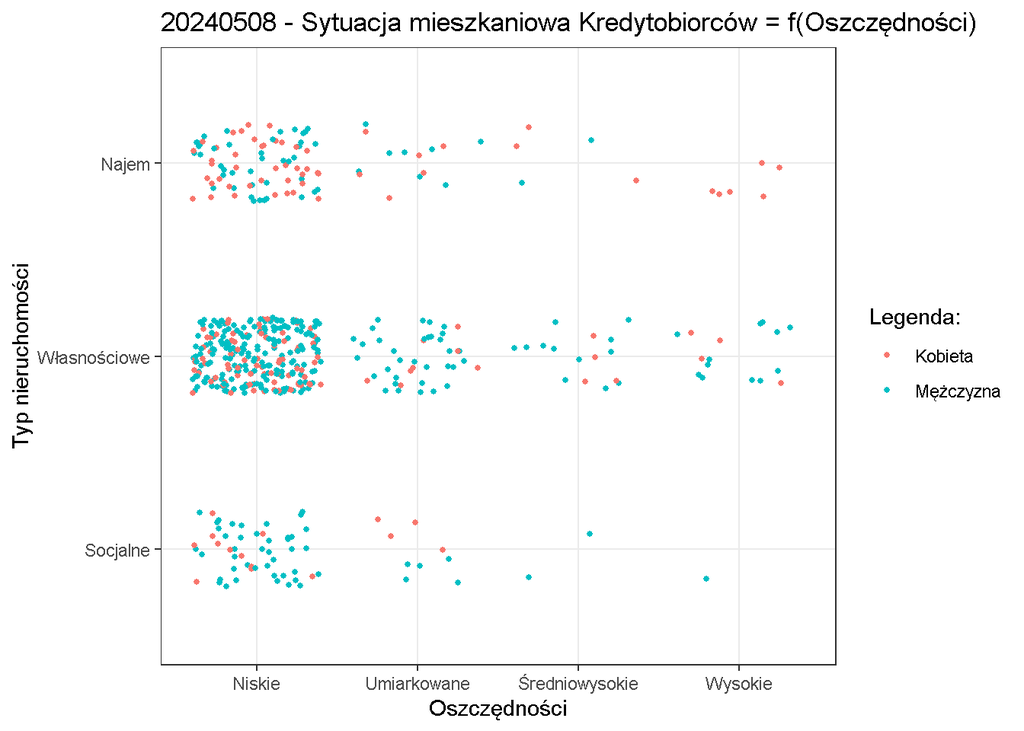

```r
### Nieruchomości, a oszczędności:
df_dane %>%
  ggplot() +
  geom_jitter(aes(x = Rachunek_oszczędnościowy, y = Nieruchomości, col = Płeć),
              height = 0.2,
              size = integer_rozmiar_punktu_danych_na_wykresach) +
  theme_bw() +
  labs(title = "20240508 - Sytuacja mieszkaniowa Kredytobiorców = f(Oszczędności)",
       x = "Oszczędności", y = "Typ nieruchomości",
       col = "Legenda:")
```

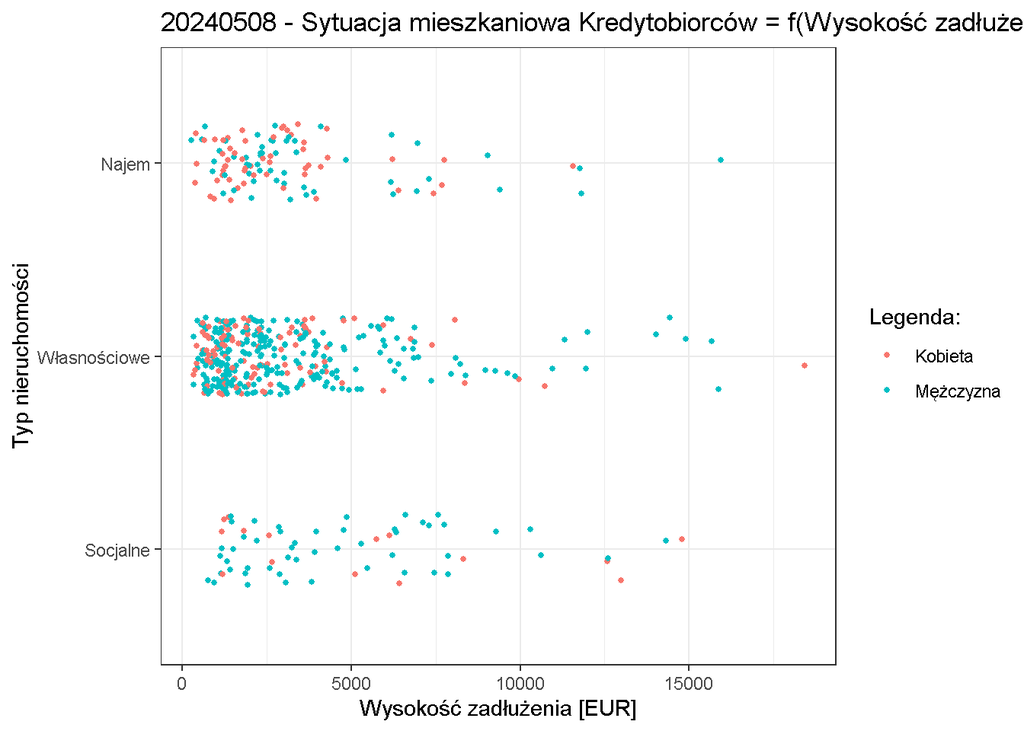

```r
### Nieruchomości, a wysokość zadłużenia:
df_dane %>%
  ggplot() +
  geom_jitter(aes(x = Wysokość_kredytu, y = Nieruchomości, col = Płeć),
              height = 0.2,
              size = integer_rozmiar_punktu_danych_na_wykresach) +
  theme_bw() +
  labs(title = "20240508 - Sytuacja mieszkaniowa Kredytobiorców = f(Wysokość zadłużenia)",
       x = "Wysokość zadłużenia [EUR]", y = "Typ nieruchomości",
       col = "Legenda:")
```

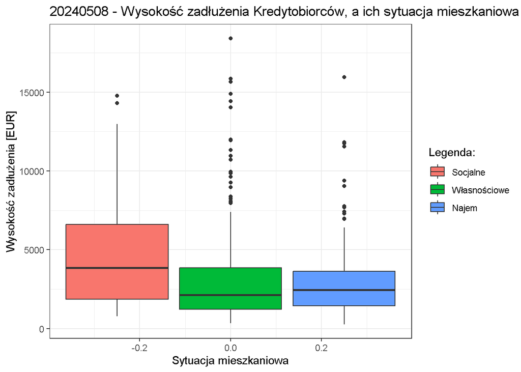

```r
df_dane %>%
  ggplot() +
  geom_boxplot(aes(y = Wysokość_kredytu, fill = Nieruchomości)) +
  theme_bw() +
  labs(title = "20240508 - Wysokość zadłużenia Kredytobiorców, a ich sytuacja mieszkaniowa",
       x = "Sytuacja mieszkaniowa", y = "Wysokość zadłużenia [EUR]", fill = "Legenda:")
```

### 2.3.4. Oszczędności

```r
### Wysokość oszczędności - bez podziału na płeć:
wektor_wysokosc_oszczednosci_w_badanej_probie <- table(df_dane$Rachunek_oszczędnościowy)
names(wektor_wysokosc_oszczednosci_w_badanej_probie) <- c("Niskie [Liczba]",
                                                          "Umiarkowane [Liczba]",
                                                          "Średniowysokie [Liczba]",
                                                          "Wysokie [Liczba]")
wektor_wysokosc_oszczednosci_w_badanej_probie_procenty <-
  funkcja_konwersja_wartosci_wektora_na_procenty(wektor_wysokosc_oszczednosci_w_badanej_probie,1)
names(wektor_wysokosc_oszczednosci_w_badanej_probie_procenty) <- c("Niskie [%]",
                                                              "Umiarkowane [%]",
                                                              "Średniowysokie [%]",
                                                              "Wysokie [%]")
wektor_wysokosc_oszczednosci_w_badanej_probie
```

```
##         Niskie [Liczba]    Umiarkowane [Liczba] Średniowysokie [Liczba]
##                     412                      64                      23
##        Wysokie [Liczba]
##                      23
```

```r
wektor_wysokosc_oszczednosci_w_badanej_probie_procenty
```

```
##         Niskie [%]    Umiarkowane [%] Średniowysokie [%]        Wysokie [%]
##               78.9               12.3                4.4                4.4
```

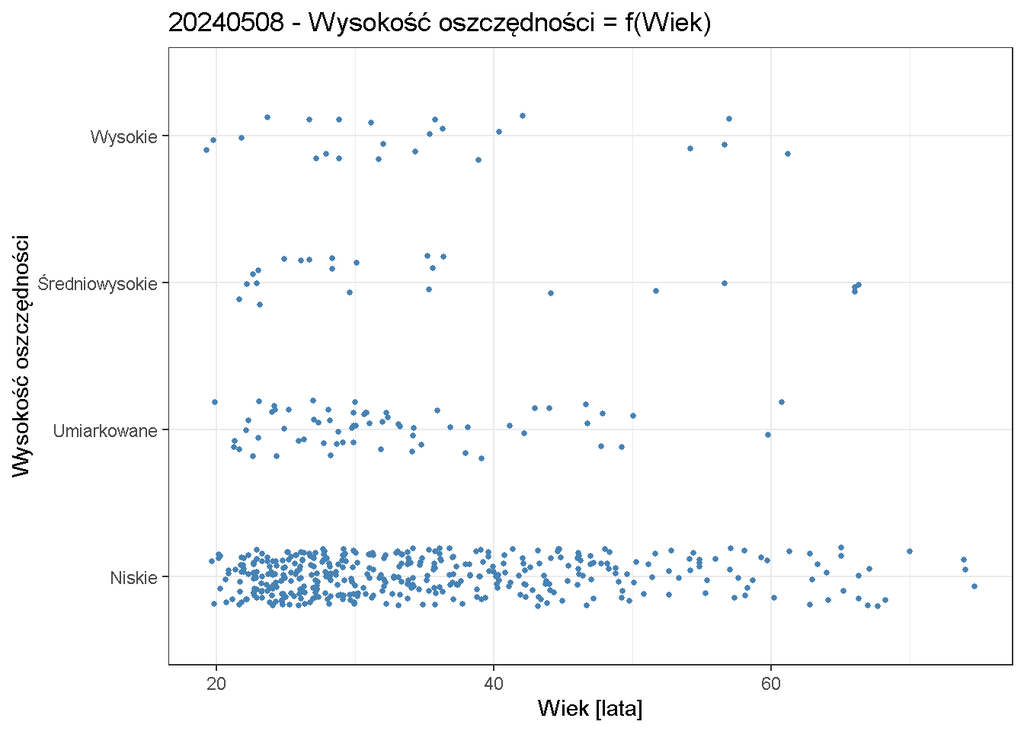

```r
df_dane %>%
  ggplot() +
  geom_jitter(aes(x = Wiek, y = Rachunek_oszczędnościowy),
              color = string_kolor_punktu_danych_na_wykresach,
              height = 0.2,
              size = integer_rozmiar_punktu_danych_na_wykresach) +
  theme_bw() +
  labs(title = "20240508 - Wysokość oszczędności = f(Wiek)",
       x = "Wiek [lata]", y = "Wysokość oszczędności")
```

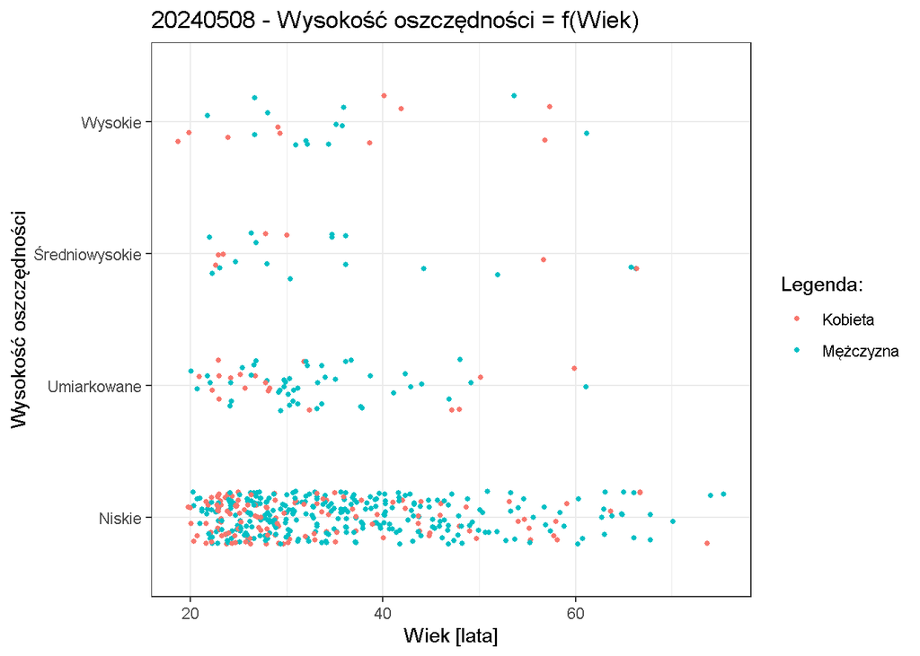

```r
### Wysokość oszczędności - z podziałem na płeć:
df_dane %>%
  ggplot() +
  geom_jitter(aes(x = Wiek, y = Rachunek_oszczędnościowy, col = Płeć),
              height = 0.2,
              size = integer_rozmiar_punktu_danych_na_wykresach) +
  theme_bw() +
  labs(title = "20240508 - Wysokość oszczędności = f(Wiek)",
       x = "Wiek [lata]", y = "Wysokość oszczędności",
       col = "Legenda:")
```

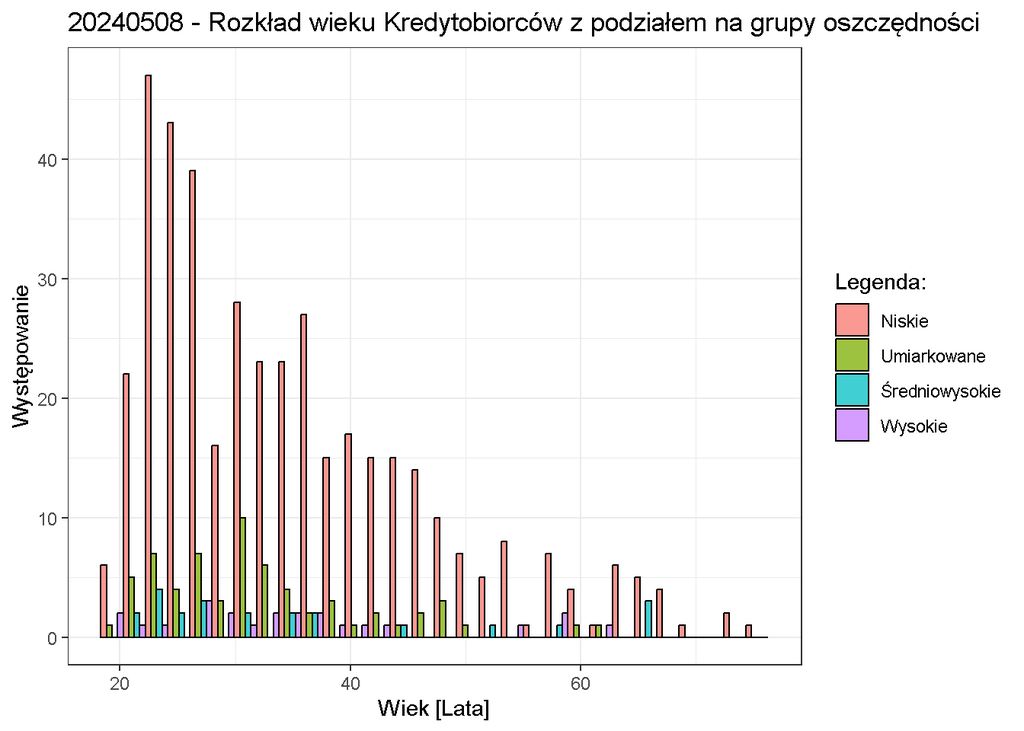

```r
df_dane %>%
  ggplot() +
  geom_histogram(aes(x = Wiek, fill = Rachunek_oszczędnościowy),
                 alpha = 0.75, position = "dodge",
                 colour = "black") +
  theme_bw() +
  labs(title = "20240508 - Rozkład wieku Kredytobiorców z podziałem na grupy oszczędności",
       x = "Wiek [Lata]", y = "Występowanie", fill="Legenda:")
```

### 2.3.5. Saldo bieżące

```r
### Rachunek bieżący - bez podziału na płeć:
wektor_saldo_biezace_w_badanej_probie <- table(df_dane$Rachunek_bieżący)
names(wektor_saldo_biezace_w_badanej_probie) <- c("Niskie [Liczba]",
                                                  "Umiarkowane [Liczba]",
                                                  "Wysokie [Liczba]")
wektor_saldo_biezace_w_badanej_probie_procenty <-
  funkcja_konwersja_wartosci_wektora_na_procenty(wektor_saldo_biezace_w_badanej_probie,1)
names(wektor_saldo_biezace_w_badanej_probie_procenty) <- c("Niskie [%]",
                                                           "Umiarkowane [%]",
                                                           "Wysokie [%]")
wektor_saldo_biezace_w_badanej_probie
```

```
##      Niskie [Liczba] Umiarkowane [Liczba]     Wysokie [Liczba]
##                  245                  224                   53
```

```r
wektor_saldo_biezace_w_badanej_probie_procenty
```

```
##      Niskie [%] Umiarkowane [%]     Wysokie [%]
##            46.9            42.9            10.2
```

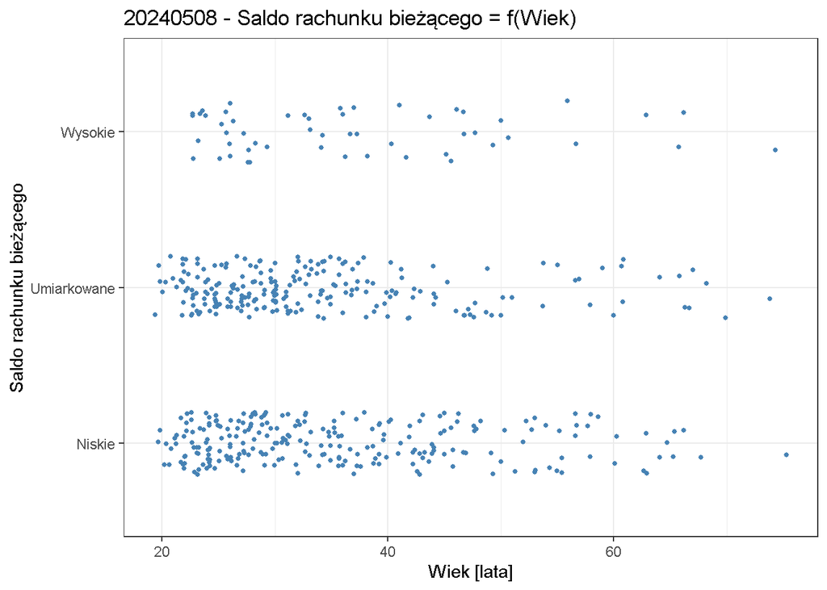

```r
df_dane %>%
  ggplot() +
  geom_jitter(aes(x = Wiek, y = Rachunek_bieżący),
              color = string_kolor_punktu_danych_na_wykresach,
              height = 0.2,
              size = integer_rozmiar_punktu_danych_na_wykresach) +
  theme_bw() +
  labs(title = "20240508 - Saldo rachunku bieżącego = f(Wiek)",
       x = "Wiek [lata]", y = "Saldo rachunku bieżącego")
```

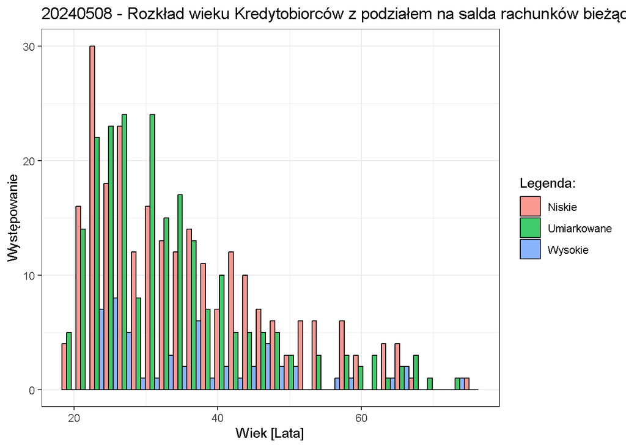

```r
df_dane %>%
  ggplot() +
  geom_histogram(aes(x = Wiek, fill = Rachunek_bieżący),
                 alpha = 0.75, position = "dodge",
                 colour = "black") +
  theme_bw() +
  labs(title = "20240508 - Rozkład wieku Kredytobiorców z podziałem na salda rachunków bieżących",
       x = "Wiek [Lata]", y = "Występowanie", fill="Legenda:")
```

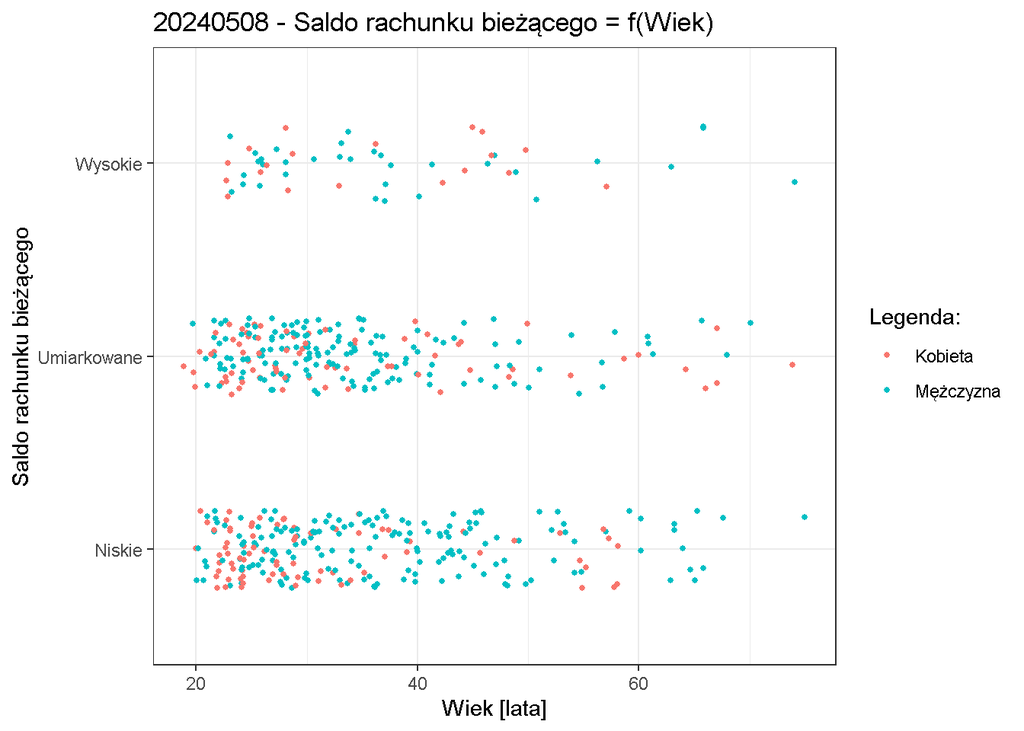

```r
### Rachunek bieżący - z podziałem na płeć:
df_dane %>%
  ggplot() +
  geom_jitter(aes(x = Wiek, y = Rachunek_bieżący, col = Płeć),
              height = 0.2,
              size = integer_rozmiar_punktu_danych_na_wykresach) +
  theme_bw() +
  labs(title = "20240508 - Saldo rachunku bieżącego = f(Wiek)",
       x = "Wiek [lata]", y = "Saldo rachunku bieżącego",
       col = "Legenda:")
```

### 2.3.6. Wysokość kredytu

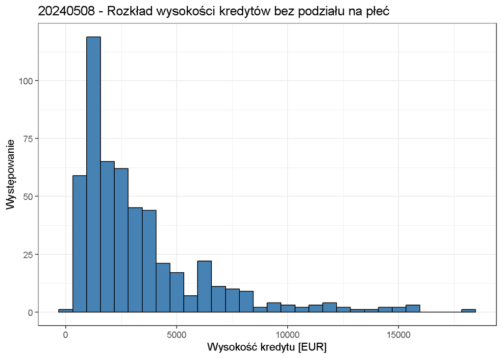

```r
### Wysokość kredytu - bez podziału na płeć:
df_dane %>%
  ggplot() +
  geom_histogram(aes(x = Wysokość_kredytu),
                 fill = string_kolor_punktu_danych_na_wykresach,
                 colour = "black") +
  theme_bw() +
  labs(title = "20240508 - Rozkład wysokości kredytów bez podziału na płeć",
       x = "Wysokość kredytu [EUR]", y = "Występowanie")
```

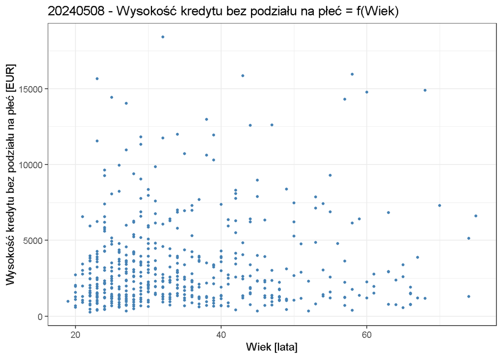

```r
df_dane %>%
  ggplot() +
  geom_point(aes(x = Wiek, y = Wysokość_kredytu),
             color = string_kolor_punktu_danych_na_wykresach,
             size = integer_rozmiar_punktu_danych_na_wykresach) +
  theme_bw() +
  labs(title = "20240508 - Wysokość kredytu bez podziału na płeć = f(Wiek)",
       x = "Wiek [lata]", y = "Wysokość kredytu bez podziału na płeć [EUR]")
```

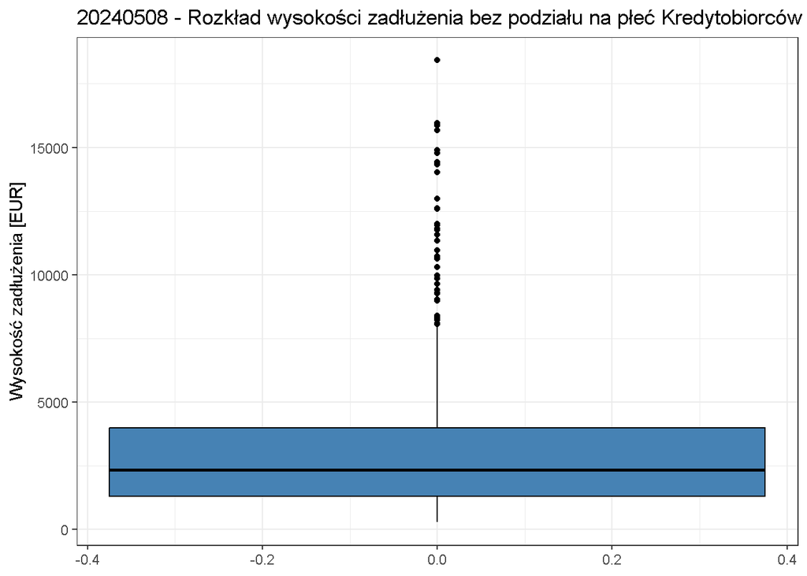

```r
df_dane %>%
  ggplot() +
  geom_boxplot(aes(y = Wysokość_kredytu),
               fill = string_kolor_punktu_danych_na_wykresach,
               color = "black") +
  theme_bw() +
  labs(title = "20240508 - Rozkład wysokości zadłużenia bez podziału na płeć Kredytobiorców",
       y = "Wysokość zadłużenia [EUR]")
```